# 3. Facial Keypoint Detection, Complete Pipeline

## Dear Grader, I spent a lot of time trying different approaches to make the keypoints appear where they should.

## But the NN keeps outputing values in the range of [-50,50], despite the previous workbook functioning correctly (values in the range [-1,1]).

## Need to move on.., submitting as is.

## Face and Facial Keypoint detection

After you've trained a neural network to detect facial keypoints, you can then apply this network to *any* image that includes faces. The neural network expects a Tensor of a certain size as input and, so, to detect any face, you'll first have to do some pre-processing.

1. Detect all the faces in an image using a face detector (we'll be using a Haar Cascade detector in this notebook).
2. Pre-process those face images so that they are grayscale, and transformed to a Tensor of the input size that your net expects. This step will be similar to the `data_transform` you created and applied in Notebook 2, whose job was tp rescale, normalize, and turn any iimage into a Tensor to be accepted as input to your CNN.
3. Use your trained model to detect facial keypoints on the image.

In the next python cell we load in required libraries for this section of the project.

```python
import numpy as np
import matplotlib.pyplot as plt
import matplotlib.image as mpimg
%matplotlib inline
```

#### Select an image

Select an image to perform facial keypoint detection on; you can select any image of faces in the `images/` directory.

[figure not shown]

```python
import cv2
# load in color image for face detection
image = mpimg.imread('images/obamas.jpg')
#image = cv2.imread('images/mona_lisa.jpg')
#image = cv2.imread('data/test/Abdullah_Gul_10.jpg')

# switch red and blue color channels
# --> by default OpenCV assumes BLUE comes first, not RED as in many images
#image = cv2.cvtColor(image, cv2.COLOR_BGR2RGB)

# plot the image
fig = plt.figure(figsize=(9,9))
plt.imshow(image)
```

## Detect all faces in an image

Next, you'll use one of OpenCV's pre-trained Haar Cascade classifiers, all of which can be found in the `detector_architectures/` directory, to find any faces in your selected image.

In the code below, we loop over each face in the original image and draw a red square on each face (in a copy of the original image, so as not to modify the original). You can even [add eye detections](https://docs.opencv.org/3.4.1/d7/d8b/tutorial_py_face_detection.html) as an *optional* exercise in using Haar detectors.

An example of face detection on a variety of images is shown below.

[figure not shown]

[figure not shown]

```python
# load in a haar cascade classifier for detecting frontal faces
face_cascade = cv2.CascadeClassifier('detector_architectures/haarcascade_frontalface_default.xml')

# run the detector
# the output here is an array of detections; the corners of each detection box
# if necessary, modify these parameters until you successfully identify every face in a given image
faces = face_cascade.detectMultiScale(image, 1.2, 2)

# make a copy of the original image to plot detections on
image_with_detections = image.copy()

# loop over the detected faces, mark the image where each face is found
for (x,y,w,h) in faces:
    # draw a rectangle around each detected face
    # you may also need to change the width of the rectangle drawn depending on image resolution
    cv2.rectangle(image_with_detections,(x,y),(x+w,y+h),(255,0,0),3)

fig = plt.figure(figsize=(9,9))

plt.imshow(image_with_detections)
```

## Loading in a trained model

Once you have an image to work with (and, again, you can select any image of faces in the `images/` directory), the next step is to pre-process that image and feed it into your CNN facial keypoint detector.

First, load your best model by its filename.

```python
import torch
from models import Net

device = torch.device("cuda" if torch.cuda.is_available() else "cpu")

net = Net().to(device)
## load the best saved model parameters (by your path name)
## You'll need to un-comment the line below and add the correct name for *your* saved model
net.load_state_dict(torch.load('saved_models/AH_3conv_layers_epoch60.pt', map_location=torch.device(device)))

## print out your net and prepare it for testing (uncomment the line below)
net.eval()
```

```
Net(
  (conv1): Conv2d(1, 32, kernel_size=(5, 5), stride=(1, 1))
  (pool1): MaxPool2d(kernel_size=2, stride=2, padding=0, dilation=1, ceil_mode=False)
  (conv2): Conv2d(32, 64, kernel_size=(5, 5), stride=(1, 1))
  (pool2): MaxPool2d(kernel_size=2, stride=2, padding=0, dilation=1, ceil_mode=False)
  (conv3): Conv2d(64, 128, kernel_size=(3, 3), stride=(1, 1))
  (pool3): MaxPool2d(kernel_size=2, stride=2, padding=0, dilation=1, ceil_mode=False)
  (pool4): MaxPool2d(kernel_size=2, stride=2, padding=0, dilation=1, ceil_mode=False)
  (fc1): Linear(in_features=18432, out_features=360, bias=True)
  (fc1_drop): Dropout(p=0.2, inplace=False)
  (fc2): Linear(in_features=360, out_features=136, bias=True)
)
```

## Keypoint detection

Now, we'll loop over each detected face in an image (again!) only this time, you'll transform those faces in Tensors that your CNN can accept as input images.

### TODO: Transform each detected face into an input Tensor

You'll need to perform the following steps for each detected face:

1. Convert the face from RGB to grayscale
2. Normalize the grayscale image so that its color range falls in [0,1] instead of [0,255]
3. Rescale the detected face to be the expected square size for your CNN (224x224, suggested)
4. Reshape the numpy image into a torch image.

**Hint**: The sizes of faces detected by a Haar detector and the faces your network has been trained on are of different sizes. If you find that your model is generating keypoints that are too small for a given face, try adding some padding to the detected `roi` before giving it as input to your model.

You may find it useful to consult to transformation code in `data_load.py` to help you perform these processing steps.

### TODO: Detect and display the predicted keypoints

After each face has been appropriately converted into an input Tensor for your network to see as input, you can apply your `net` to each face. The ouput should be the predicted the facial keypoints. These keypoints will need to be "un-normalized" for display, and you may find it helpful to write a helper function like `show_keypoints`. You should end up with an image like the following with facial keypoints that closely match the facial features on each individual face:

[figure not shown]

```python
def load_checkpoint(filename):
    checkpoint = torch.load(filename, map_location=torch.device('cpu'))
    net.load_state_dict(checkpoint['model_state_dict'])
```

[output not shown]

[output cut: 83 more lines]

[output not shown]

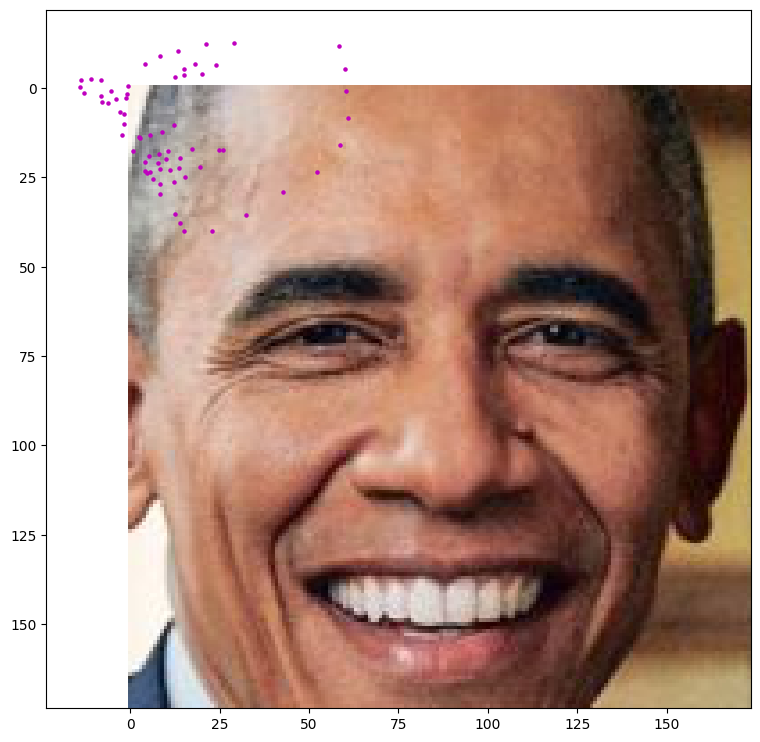

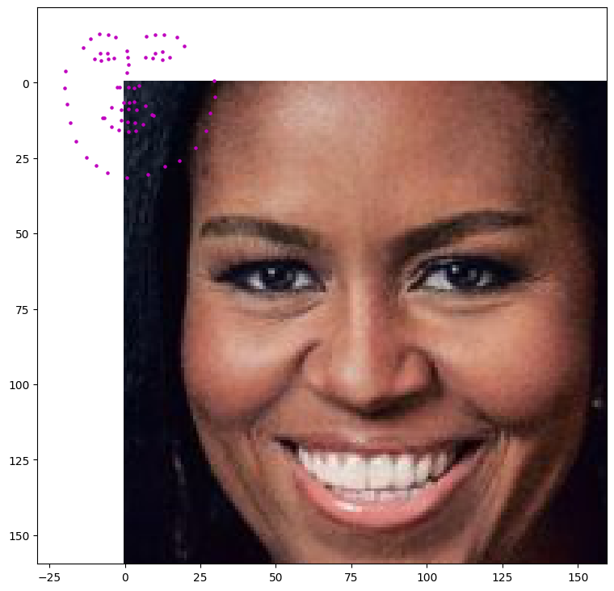

```python
PADDING = 40
image_copy = np.copy(image)
# loop over the detected faces from your haar cascade
i = 0
#net.load_state_dict(torch.load('saved_models/AH_3conv_layers_epoch60.pt', map_location=torch.device(device)))
load_checkpoint('saved_models/checkpoint_epoch71.pth')
for (x,y,w,h) in faces:
    # Select the region of interest that is the face in the image
    roi = image_copy[y:y+h, x:x+w]
    #roi = image_copy[y-PADDING:y+h+PADDING, x-PADDING:x+w+PADDING]
    roi = np.copy(roi)
    print(roi.shape)

    # if image has an alpha color channel, get rid of it
    if(roi.shape[2] == 4):
        roi = roi[:,:,0:3]

    resized = cv2.resize(roi, (224, 224))

    gray = cv2.cvtColor(resized, cv2.COLOR_RGB2GRAY)
    normalized = gray / 255

    if len(normalized.shape) == 2:
        normalized = normalized.reshape(normalized.shape[0], normalized.shape[1], 1)

    ## Reshape the numpy image shape (H x W x C) into a torch image shape (C x H x W)
    input_np = normalized.transpose((2,0,1))
    input_torch = torch.from_numpy(input_np)

    input_torch = input_torch.to(device)
    if device == 'cuda':
        input_torch = input_torch.type(type(torch.cuda.FloatTensor))
    else:
        input_torch = input_torch.float()

    input_torch = input_torch.unsqueeze(0)
    #print('input_shape: ', input_torch.shape)

    ##############################################################

    ## Make facial keypoint predictions using your loaded, trained network
    #output_pts = net(input_torch)
    output_pts = net.forward(input_torch)

    output_pts = output_pts.detach()
    output_pts = output_pts.view(output_pts.size()[0], 68, -1)
    output_pts = output_pts.cpu().numpy()[0]   # shape (68,2)
    print(output_pts)

    # undo training normalization: (pts - 100)/50 -> pts = pred*50 + 100
    #output_pts = output_pts * 50.0 + 100.0                       # now in 224x224 pixel coords

    # plot on resized ROI (matches the coordinate system)
    plt.figure(figsize=(20, 10))
    ax = plt.subplot(1, len(faces), i + 1)
    plt.imshow(roi, cmap='gray')  # resized grayscale
    plt.scatter(output_pts[:, 0], output_pts[:, 1], s=20, marker='.', c='m')
    #plt.axis('off')
    i += 1
plt.show()
```

[figure not shown]

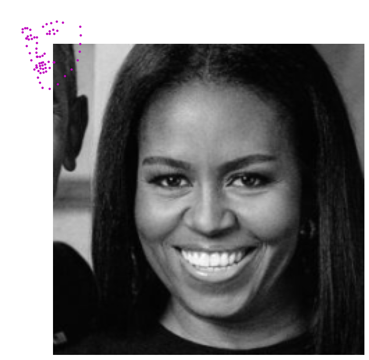

```python
image_copy = np.copy(image)
# loop over the detected faces from your haar cascade
i = 0
for (x,y,w,h) in faces:

    plt.figure(figsize=(20,10))
    ax = plt.subplot(1, len(faces), i+1)
    i += 1

    # Select the region of interest which is the face in the image
    margin = 0.3
    roi = image_copy[y-int(margin*h):y+h+int(margin*h), x-int(margin*w):x+w+int(margin*w)]

    ## TODO: Convert the face region from RGB to grayscale
    roi = cv2.cvtColor(roi, cv2.COLOR_RGB2GRAY)
    ## TODO: Normalize the grayscale image so that its color range falls in [0,1] instead of [0,255]
    roi =  roi/255.0

    ## TODO: Rescale the detected face to be the expected square size for your CNN (224x224, suggested)
    output_size = 224

    new_h, new_w = output_size, output_size
    roi = cv2.resize(roi, (new_w, new_h))


    ## TODO: Reshape the numpy image shape (H x W x C) into a torch image shape (C x H x W)
    # add that third color dim
    roi_reshaped = roi.reshape(roi.shape[0], roi.shape[1], 1)

    # swap color axis because
    # numpy image: H x W x C
    # torch image: C X H X W

    roi_transpose = roi_reshaped.transpose((2, 0, 1))

    roi_transpose = roi_transpose.reshape(1, roi_transpose.shape[0], roi_transpose.shape[1], roi_transpose.shape[2])

    roi_tensor = torch.from_numpy(roi_transpose)

    dtype = torch.cuda.FloatTensor

    # convert images to FloatTensors
    roi_tensor = roi_tensor.type(dtype)

    ## TODO: Make facial keypoint predictions using your loaded, trained network
    ## perform a forward pass to get the predicted facial keypoints
    predicted_key_pts = net(roi_tensor)

    # reshape to batch_size x 68 x 2 pts
    predicted_key_pts = predicted_key_pts.view(68, -1)

    predicted_key_pts = predicted_key_pts.data
    predicted_key_pts = predicted_key_pts.cpu().numpy()

    # undo normalization of keypoints
    #predicted_key_pts = predicted_key_pts*50.0+100
    ## TODO: Display each detected face and the corresponding keypoints
    # image is grayscale
    plt.imshow(roi, cmap='gray')
    plt.scatter(predicted_key_pts[:, 0], predicted_key_pts[:, 1], s=20, marker='.', c='m')
    plt.axis('off')

plt.show()
```

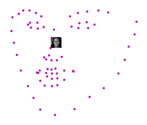

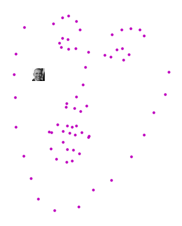

```python
def show_all_keypoints(image, keypoints):
    batch_size = len(image)
    for i, face in enumerate(image):
        plt.figure(figsize=(8, 8))
        ax = plt.subplot(1, batch_size, i+1)
        # un-transform the predicted key_pts data
        predicted_keypoints = keypoints[i].data
        predicted_keypoints = predicted_keypoints.numpy()
        # undo normalization of keypoints
        predicted_keypoints = predicted_keypoints*50.0+100
        plt.imshow(face, cmap='gray')
        plt.scatter(predicted_keypoints[:, 0], predicted_keypoints[:, 1], s=20, marker='.', c='m')

        plt.axis('off')
    plt.show()

image_copy = np.copy(image)
#Including a padding to extract face as  HAAR classifier's bounding box, crops sections of the face
PADDING = 40
images, keypoints = [], []
# loop over the detected faces from your haar cascade
for (x,y,w,h) in faces:

    # Select the region of interest that is the face in the image
    roi = image_copy[y-PADDING:y+h+PADDING, x-PADDING:x+w+PADDING]

    ## Convert the face region from RGB to grayscale
    roi = cv2.cvtColor(roi, cv2.COLOR_RGB2GRAY)

    ## Normalize the grayscale image so that its color range falls in [0,1] instead of [0,255]
    roi = (roi / 255.).astype(np.float32)

    ## Rescale the detected face to be the expected square size for your CNN (224x224, suggested)
    roi = cv2.resize(roi, (224, 224))
    images.append(roi)

    ## Reshape the numpy image shape (H x W x C) into a torch image shape (C x H x W)
    if len(roi.shape) == 2:
        roi = np.expand_dims(roi, axis=0)
    else:
        roi = np.rollaxis(roi, 2, 0)

    # Match the convolution dimensions
    roi = np.expand_dims(roi, axis=0)

    ## Make facial keypoint predictions using your loaded, trained network
    # Forward pass
    roi = torch.from_numpy(roi).type(torch.FloatTensor)
    output_pts = net.forward(roi)

    output_pts = output_pts.view(output_pts.size()[0], 68, -1)
    keypoints.append(output_pts[0])

## Display each detected face and the corresponding keypoints
show_all_keypoints(images, keypoints)
```

```python
from torch.utils.data import Dataset, DataLoader
from torchvision import transforms, utils

# the transforms we defined in Notebook 1 are in the helper file `data_load.py`
from data_load import Rescale, Normalize, ToTensor

class NumpyImageDataset(Dataset):
    def __init__(self, images, transform=None):
        """
        Args:
            images (list of np.ndarray): List of images, each a numpy array
                                         (e.g. from mpimg.imread).
            transform (callable, optional): Optional transform to be applied
                                            on a sample (e.g. torchvision transforms).
        """
        # Basic validation
        if not isinstance(images, list):
            raise TypeError("images must be a list of numpy arrays")
        if not all(isinstance(img, np.ndarray) for img in images):
            raise ValueError("all elements in images must be numpy arrays")

        self.images = images
        self.transform = transform

    def __len__(self):
        return len(self.images)

    def __getitem__(self, idx):
        # Get image
        image = self.images[idx]

        # if image has an alpha color channel, get rid of it
        if(image.shape[2] == 4):
            image = image[:,:,0:3]

        sample = {'image': np.copy(image), 'keypoints': np.empty((0, 2), dtype=float)}

        if self.transform:
            sample = self.transform(sample)

        return sample
```

```python
data_transform = transforms.Compose([Rescale((224,224)),
                                     Normalize(),
                                     ToTensor()])
```

```python
image_copy = np.copy(image)
#Including a padding to extract face as  HAAR classifier's bounding box, crops sections of the face
PADDING = 40
rois = []
# loop over the detected faces from your haar cascade
for (x,y,w,h) in faces:
    # Select the region of interest that is the face in the image
    roi = image_copy[y-PADDING:y+h+PADDING, x-PADDING:x+w+PADDING]
    rois.append(np.copy(roi))

rois_dataset = NumpyImageDataset(rois, data_transform)

batch_size = 10
loader = DataLoader(rois_dataset,
                    batch_size=batch_size,
                    shuffle=False,
                    num_workers=0)
```

```python
def get_output():
    for i, sample in enumerate(loader):
        images = sample['image'].to(device)
        images = images.type(torch.cuda.FloatTensor)
        output_pts = net(images)
        output_pts = output_pts.view(output_pts.size()[0], 68, -1)
        #print(output_pts)
        if i == 0:
            return output_pts.detach().cpu()
```

```python
def show_all_keypoints(keypoints):
    batch_size = len(image)
    for i, (x,y,w,h) in enumerate(faces):
        face = image_copy[y-PADDING:y+h+PADDING, x-PADDING:x+w+PADDING]
        face = cv2.cvtColor(face, cv2.COLOR_RGB2GRAY)
        face = (face / 255.).astype(np.float32)
        face = cv2.resize(face, (224, 224))

        plt.figure(figsize=(8, 8))
        ax = plt.subplot(1, len(faces), i+1)
        # un-transform the predicted key_pts data
        predicted_keypoints = keypoints[i]
        predicted_keypoints = predicted_keypoints.cpu().numpy()
        # undo normalization of keypoints
        predicted_keypoints = predicted_keypoints*50.0+100
        plt.imshow(face, cmap='gray')
        plt.scatter(predicted_keypoints[:, 0], predicted_keypoints[:, 1], s=20, marker='.', c='m')
        plt.axis('off')
    plt.show()
```

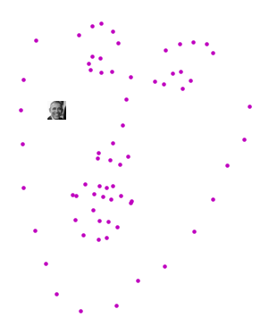

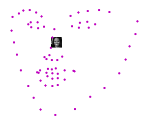

```python
keypoints = get_output()
show_all_keypoints(keypoints)
```